# Practical Machine Learning Quiz 2

Andrew E. Davidson

September 22, 2015

For this quiz we will be using several R packages. R package versions change over time, the right answers have been checked using the following versions of the packages.

AppliedPredictiveModeling: v1.1.6 caret: v6.0.47

If you aren’t using these versions of the packages, your answers may not exactly match the right answer, but hopefully should be close.

## Question 1

Load the Alzheimer’s disease data using the commands:

```r
library(AppliedPredictiveModeling)
library(caret)
data(AlzheimerDisease)
```

Which of the following commands will create training and test sets with about 50% of the observations assigned to each?

```r
adData = data.frame(diagnosis,predictors)
trainIndex = createDataPartition(diagnosis, p = 0.50,list=FALSE)
training = adData[trainIndex,]
testing = adData[-trainIndex,]
length(diagnosis); dim(training); dim(testing)
```

```
## [1] 333
```

```
## [1] 167 131
```

```
## [1] 166 131
```

## Question 2

Load the cement data using the commands:

```r
library(AppliedPredictiveModeling)
data(concrete)
library(caret)
set.seed(1000)
inTrain = createDataPartition(mixtures$CompressiveStrength, p = 3/4)[[1]]
training = mixtures[ inTrain,]
testing = mixtures[-inTrain,]
```

Make a histogram and confirm the SuperPlasticizer variable is skewed. Normally you might use the log transform to try to make the data more symmetric. Why would that be a poor choice for this variable?

```
## stat_bin: binwidth defaulted to range/30. Use 'binwidth = x' to adjust this.
```

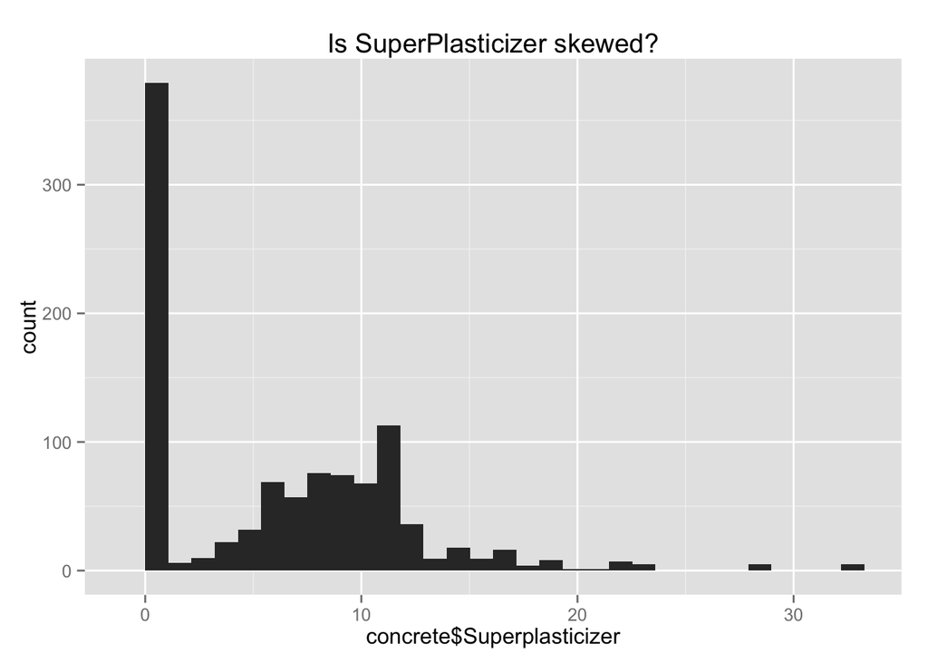

```r
library(ggplot2)
qplot(concrete$Superplasticizer, geom="histogram") + ggtitle("Is SuperPlasticizer skewed?")
```

```r
length(concrete$Superplasticizer);length(which(concrete$Superplasticizer == 0))
```

```
## [1] 1030
```

```
## [1] 379
```

poor chose becuase log(0) is undefined

## Question 3

Load the Alzheimer’s disease data using the commands:

```r
library(caret)
library(AppliedPredictiveModeling)
set.seed(3433)
data(AlzheimerDisease)
adData = data.frame(diagnosis,predictors)
inTrain = createDataPartition(adData$diagnosis, p = 3/4)[[1]]
training = adData[ inTrain,]
testing = adData[-inTrain,]
```

Find all the predictor variables in the training set that begin with IL. Perform principal components on these variables with the preProcess() function from the caret package. Calculate the number of principal components needed to capture 80% of the variance. How many are there?

```r
#startsWith_IL <- names(predictors)
startsWith_IL<- predictors[,grep("^IL", names(predictors))]

#preProc <- preProcess(log10(startsWith_IL),method="pca",pcaComp=2)
#preProc <- preProcess(log10(startsWith_IL),method="pca")
preProc <- preProcess(startsWith_IL,method="pca", thresh=0.8)
preProc
```

```
##
## Call:
## preProcess.default(x = startsWith_IL, method = "pca", thresh = 0.8)
##
## Created from 333 samples and 12 variables
## Pre-processing: principal component signal extraction, scaled, centered
##
## PCA needed 7 components to capture 80 percent of the variance
```

## Question 4

Load the Alzheimer’s disease data using the commands:

```r
library(caret)
library(AppliedPredictiveModeling)
set.seed(3433)
data(AlzheimerDisease)
adData = data.frame(diagnosis,predictors)
inTrain = createDataPartition(adData$diagnosis, p = 3/4)[[1]]
training = adData[ inTrain,]
testing = adData[-inTrain,]
```

Create a training data set consisting of only the predictors with variable names beginning with IL and the diagnosis. Build two predictive models, one using the predictors as they are and one using PCA with principal components explaining 80% of the variance in the predictors. Use method=“glm” in the train function. What is the accuracy of each method in the test set? Which is more accurate?

```r
trainData <- training[, grep("^IL", names(predictors))]
modelFit <- train(training$diagnosis ~ .,method="glm",data=trainData)
modelFit
```

```
## Generalized Linear Model
##
## 251 samples
##  11 predictors
##   2 classes: 'Impaired', 'Control'
##
## No pre-processing
## Resampling: Bootstrapped (25 reps)
##
## Summary of sample sizes: 251, 251, 251, 251, 251, 251, ...
##
## Resampling results
##
##   Accuracy  Kappa  Accuracy SD  Kappa SD
##   0.7       0.1    0.04         0.1
##
##
```

```r
preProc <- preProcess(trainData,method="pca")
trainPCA <- predict(preProc,trainData)
modelFitPCA <- train(training$diagnosis ~ .,method="glm",data=trainPCA)
modelFitPCA
```

```
## Generalized Linear Model
##
## 251 samples
##   9 predictors
##   2 classes: 'Impaired', 'Control'
##
## No pre-processing
## Resampling: Bootstrapped (25 reps)
##
## Summary of sample sizes: 251, 251, 251, 251, 251, 251, ...
##
## Resampling results
##
##   Accuracy  Kappa  Accuracy SD  Kappa SD
##   0.7       0.2    0.05         0.1
##
##
```

question 4 answer is a random guess

turns out the correct answer is “Non-PCA Accuracy: 0.65 PCA Accuracy: 0.72”